# Model fitting

Tobias Ludwig

06/01/2022

# Model fitting

Model fitting was performed with respect to:

- $\alpha$: length scale
- $\beta$: UCB weight (directed exploration)
- $\gamma$: discounting factor
- $\tau$: undirected exploration

We have fit these parameters on a subject level, ignoring the different tree sizes within subject. This way, there are 3 heights * 3 breadths * 15 walks = 135 trials per subject to fit 4 parameters. In the bottom of this file, there are some supplementary analyses wrt how tree size influences the fits.

## Subject fits

To reproduce and create the csv of the best fits, run `Rscript fit_subject.R SUBJECT_ID RECOV_FLAG` for each subject (`RECOV_FLAG = TRUE` for recovering data) or directly use the corresponding shell script for either a SLURM or a PBS based cluster.

```r
df_fits <- read.csv("../fit/all_DE_subject.csv")
#df_fits <- read.csv("../fit/all_DE_recov_subject.csv")
#df_fits <- read.csv("../fit/all_DE_alpha0_subject.csv")
#df_fits <- read.csv("../fit/all_DE_subject.csv")
# exclude low-performing subjects
ids_lowperf <- c(36, 46, 59, 80, 86, 96, 100, 101)
df_fits <- df_fits %>% filter(!subjID %in% ids_lowperf) # & !subjID %in% c(18,82)) # TODO 18,82

df_fits$A <- as.factor(df_fits$A)
nrow(df_fits)
```

```
## [1] 98
```

### Log likelihoods

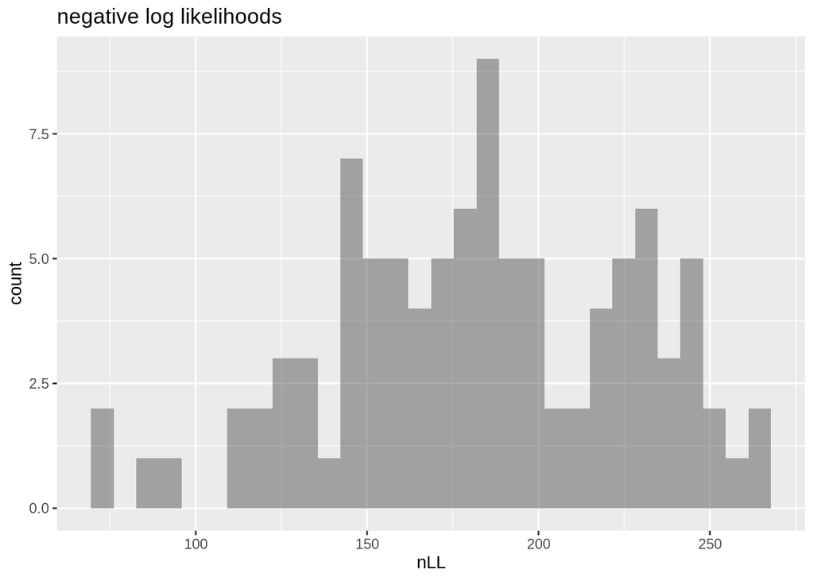

```r
ggplot(df_fits, aes(x = nLL)) +
  geom_histogram(position="identity", alpha=.5, bins = 30) +
  labs(title = "negative log likelihoods")
```

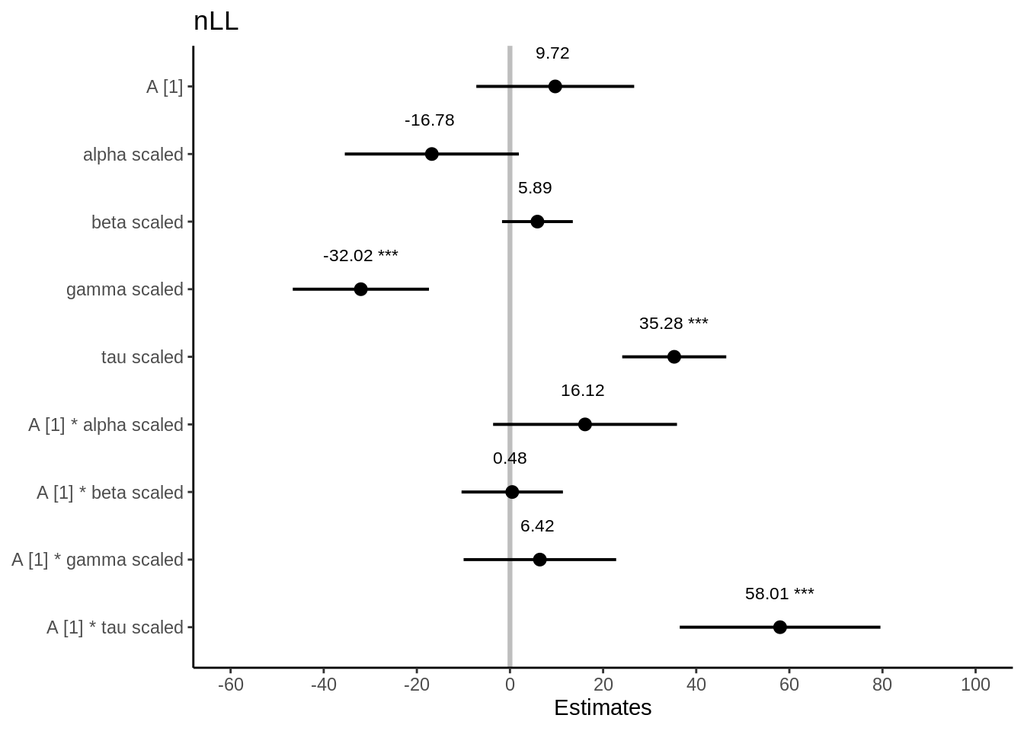

```r
df_fits <- df_fits %>% # TODO scale here???
  mutate(alpha_scaled = scale(alpha),
         beta_scaled = scale(beta),
         gamma_scaled = scale(gamma),
         tau_scaled = scale(tau))
lm_subject <- lm(nLL ~ 1 + A + (alpha_scaled*A) + (beta_scaled*A) + (gamma_scaled*A) + (tau_scaled*A), # + (alpha*tau),
                 df_fits)
plot_model(lm_subject, bpe = "mean", bpe.style = "dot", bpe.color='black', show.values = TRUE,
           vline.color = 'grey', colors = "black", value.offset = .5, value.size = 3) +
  theme_classic()
```

### Best parameters

```r
# df_fits <- df_fits %>%
#   filter(alpha <= mean(alpha) + 3*sd(alpha),
#          beta  <= mean(beta)  + 3*sd(beta),
#          gamma <= mean(gamma) + 3*sd(gamma),
#          tau   <= mean(tau)   + 3*sd(tau))
#
# nrow(df_fits)
```

```r
df_fits_m <- df_fits %>%
  group_by(A) %>%
  summarise(alpha_m = mean(alpha), alpha_se = sd(alpha) / sqrt(n()),
            beta_m  = mean(beta),  beta_se  = sd(beta)  / sqrt(n()),
            gamma_m = mean(gamma), gamma_se = sd(gamma) / sqrt(n()),
            tau_m   = mean(tau),   tau_se   = sd(tau)   / sqrt(n()))
```

### Generalization and discounting

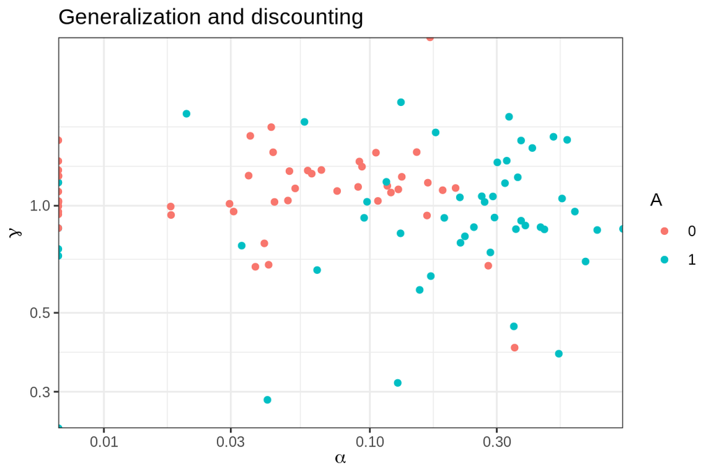

```r
df_tmp <- df_fits %>% filter(A == 1)
cor(df_tmp$alpha, df_tmp$gamma)
```

```
## [1] 0.05938405
```

```r
cor(df_tmp$alpha, df_tmp$beta)
```

```
## [1] 0.1450355
```

```r
cor(df_tmp$alpha, df_tmp$tau)
```

```
## [1] 0.1494796
```

```r
cor(df_tmp$beta,  df_tmp$tau)
```

```
## [1] -0.2358799
```

**People make use of the structure** A=1 trees are better fit by higher $\alpha$ than A=0 trees.

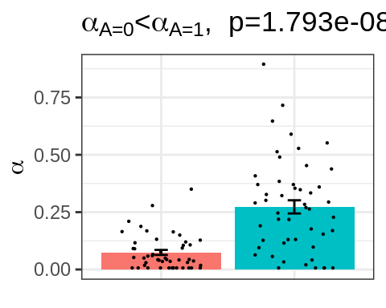

**People need to look further ahead in unstructured trees**

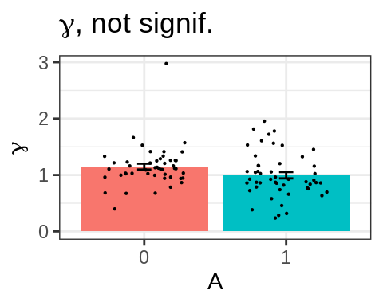

### (Un)directed Exploration

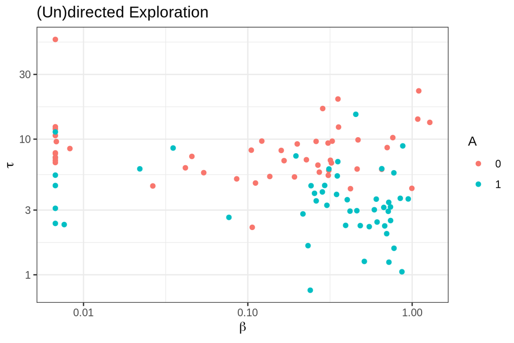

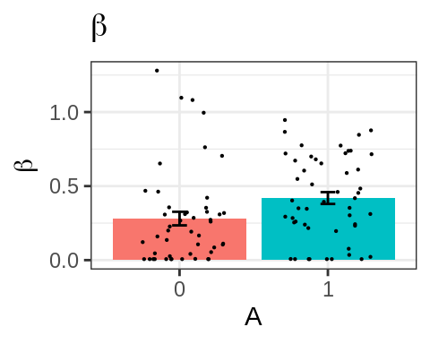

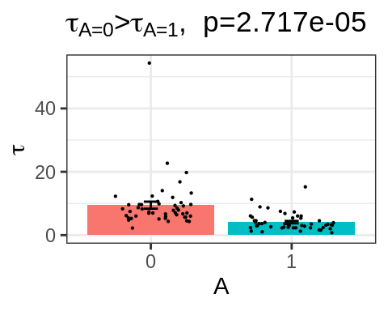

## All effects

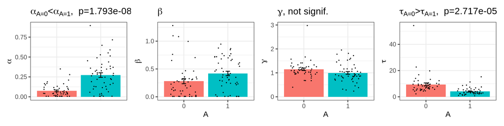

```r
p_alpha | p_beta | p_gamma | p_tau
```

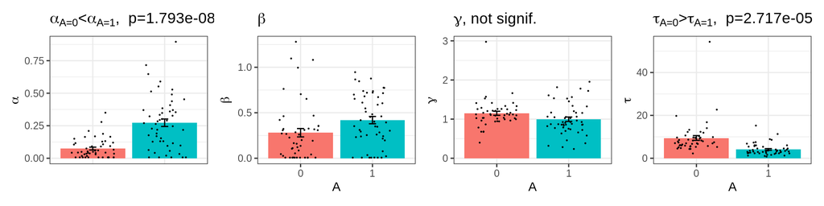

```r
p_alpha | p_beta | p_gamma | p_tau
```

All parameters in a single plot on log scale:

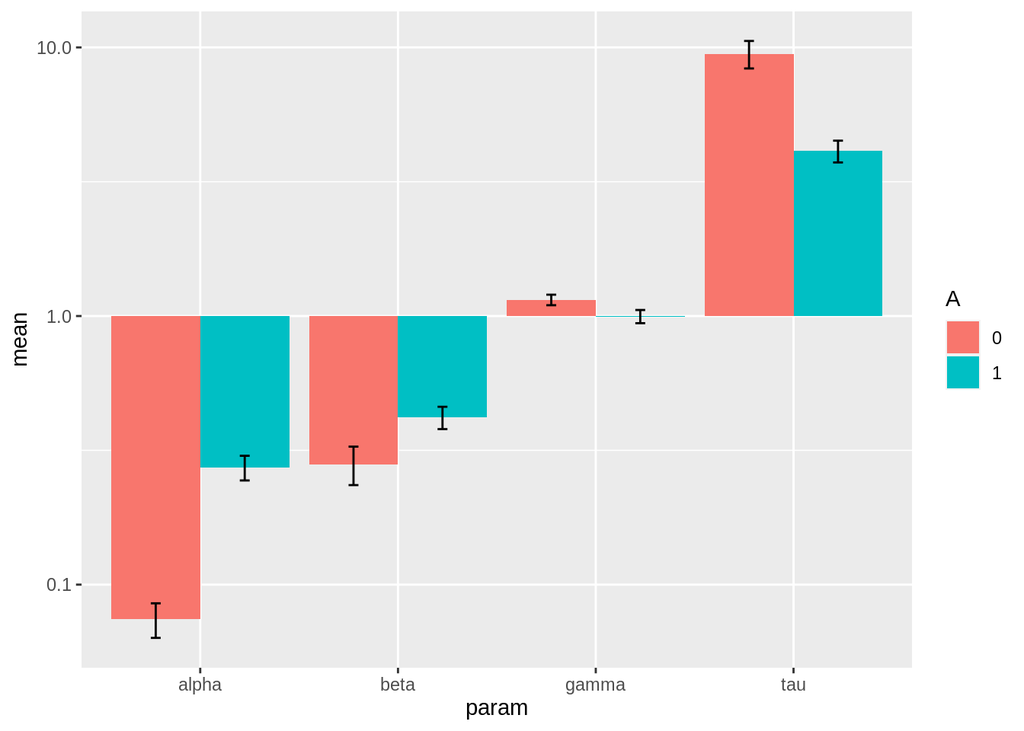

```r
df_fits_mean <- df_fits_m %>%
  dplyr::select("A", "alpha_m", "beta_m", "gamma_m", "tau_m") %>%
  pivot_longer(c("alpha_m", "beta_m", "gamma_m", "tau_m"),
               names_to = c("param", "ignore"), names_sep = "_", values_to = "mean") %>%
  dplyr::select(-ignore)
df_fits_se <- df_fits_m %>%
  dplyr::select("A", "alpha_se", "beta_se", "gamma_se", "tau_se") %>%
  pivot_longer(c("alpha_se", "beta_se", "gamma_se", "tau_se"),
               names_to = c("param", "ignore"), names_sep = "_", values_to = "se") %>%
  dplyr::select(-ignore)
df_fits_stats <- left_join(df_fits_mean, df_fits_se, by = c("A", "param"))

ggplot(df_fits_stats, aes(x = param, y = mean, group = A)) +
  geom_bar(stat="identity", aes(fill = A), position = "dodge") +
  geom_errorbar(aes(ymin=mean-se, ymax=mean+se), width=.1, position = position_dodge(.9)) +
  scale_y_log10()
```

```r
  #labs(title = TeX(paste0("$\\tau_{A=0} > \\tau_{A=1}, \\; p=", formatC(p), "$")), y = TeX("$\\tau$")) +
  #theme(legend.position="none") + theme_bw()
```

Stats again:

```r
t.test(alpha~A, df_fits)
```

```
##
##  Welch Two Sample t-test
##
## data:  alpha by A
## t = -6.4535, df = 62.808, p-value = 1.793e-08
## alternative hypothesis: true difference in means between group 0 and group 1 is not equal to 0
## 95 percent confidence interval:
##  -0.2602643 -0.1371854
## sample estimates:
## mean in group 0 mean in group 1
##      0.07427803      0.27300291
```

```r
t.test(beta ~A, df_fits)
```

```
##
##  Welch Two Sample t-test
##
## data:  beta by A
## t = -2.2796, df = 93.7, p-value = 0.0249
## alternative hypothesis: true difference in means between group 0 and group 1 is not equal to 0
## 95 percent confidence interval:
##  -0.2596101 -0.0178934
## sample estimates:
## mean in group 0 mean in group 1
##       0.2805816       0.4193334
```

```r
# t.test(gamma~A, df_fits)
# t.test(tau  ~A, df_fits)
wilcox.test(alpha~A, df_fits)
```

```
##
##  Wilcoxon rank sum test with continuity correction
##
## data:  alpha by A
## W = 438, p-value = 6.241e-08
## alternative hypothesis: true location shift is not equal to 0
```

```r
wilcox.test(beta ~A, df_fits)
```

```
##
##  Wilcoxon rank sum test with continuity correction
##
## data:  beta by A
## W = 818, p-value = 0.006704
## alternative hypothesis: true location shift is not equal to 0
```

```r
wilcox.test(gamma~A, df_fits)
```

```
##
##  Wilcoxon rank sum test with continuity correction
##
## data:  gamma by A
## W = 1567, p-value = 0.009198
## alternative hypothesis: true location shift is not equal to 0
```

```r
wilcox.test(tau  ~A, df_fits)
```

```
##
##  Wilcoxon rank sum test with continuity correction
##
## data:  tau by A
## W = 2087, p-value = 2.975e-10
## alternative hypothesis: true location shift is not equal to 0
```

```r
t.test(gamma~1, mu=1, df_fits %>% filter(A==0))
```

```
##
##  One Sample t-test
##
## data:  gamma
## t = 2.8672, df = 47, p-value = 0.006181
## alternative hypothesis: true mean is not equal to 1
## 95 percent confidence interval:
##  1.044393 1.253198
## sample estimates:
## mean of x
##  1.148795
```

# $R^2$ of full and lesioned models

$$R^2 = 1 - \frac{BIC(model)}{BIC(random)}\\
BIC = -2 LL + k \cdot \log(n)\\
k = \# params = 4 \text{, or 0 for random}\\
n = \# observations = 15\cdot 9 = 135$$
The random model picks a path at random and each trial is independent. Therefore, the chance that a choice by the random agent matches a choice of the subject is $1 / \#paths = 1/B^{H-1}$.
$$\log \mathcal{L}_{\mathrm{rand}}
= \log \prod_{B=2}^4 \prod_{H=2}^4 \bigg(\frac{1}{B^{H-1}}\bigg)^{15}
= \sum_{B=2}^4 \sum_{H=2}^4 -15 (H-1) \log B
= -286.02$$

```r
ll <- 0; for(b in 2:4) for(h in 2:4) ll <- ll - 15 * log(b)*(h-1)
bic_random <- -2*ll

compute_r2 <- function(nLL, k){ 1 - (2*nLL + k*log(135)) / bic_random }
#compute_r2 <- function(nLL, k){ 1 - (2*nLL + k*2) / bic_random } # AIC!

df_full <- read.csv("../fit/all_DE_subject.csv")
df_r2 <- tibble(subjID = df_full$subjID, A = df_full$A)
df_r2$full <- compute_r2(df_full$nLL, 4) # full model has all 4 parameters

df_alpha0  <- read.csv("../fit/all_DE_alpha0_subject.csv")
df_beta0   <- read.csv("../fit/all_DE_beta0_subject.csv")
df_gamma0  <- read.csv("../fit/all_DE_gamma0_subject.csv")
df_gamma1  <- read.csv("../fit/all_DE_gamma1_subject.csv")
df_optimal <- read.csv("../fit/all_DE_optimal_subject.csv")

# TODO filter outliers (?)
# df_alpha0 <- df_alpha0 %>% filter(nLL < mean(nLL) + 3*sd(nLL))
# df_beta0  <- df_beta0  %>% filter( < mean(beta) + 3*sd(beta))

df_alpha0 <- df_alpha0 %>% mutate(alpha0 = compute_r2(nLL, 3))
df_beta0  <- df_beta0  %>% mutate(beta0  = compute_r2(nLL, 3))
df_gamma0 <- df_gamma0 %>% mutate(gamma0 = compute_r2(nLL, 3))
df_gamma1 <- df_gamma1 %>% mutate(gamma1 = compute_r2(nLL, 3))
df_optimal <- df_optimal %>% mutate(optimal = compute_r2(nLL, 2))

df_r2 <- left_join(df_r2, df_alpha0 %>% dplyr::select(subjID, alpha0), by = "subjID")
df_r2 <- left_join(df_r2, df_beta0  %>% dplyr::select(subjID, beta0),  by = "subjID")
df_r2 <- left_join(df_r2, df_gamma0 %>% dplyr::select(subjID, gamma0), by = "subjID")
df_r2 <- left_join(df_r2, df_gamma1 %>% dplyr::select(subjID, gamma1), by = "subjID")
df_r2 <- left_join(df_r2, df_optimal %>% dplyr::select(subjID, optimal), by = "subjID")

df_params <- df_full
df_params <- left_join(df_params, df_alpha0, by = c("subjID","A"), suffix = c("", ".alpha0"))
df_params <- left_join(df_params, df_beta0 , by = c("subjID","A"), suffix = c("", ".beta0"))
df_params <- left_join(df_params, df_gamma0, by = c("subjID","A"), suffix = c("", ".gamma0"))
df_params <- left_join(df_params, df_gamma1, by = c("subjID","A"), suffix = c("", ".gamma1"))
df_params <- left_join(df_params, df_optimal, by = c("subjID","A"), suffix = c("", ".optimal"))
```

```r
# exclude low-performing subjects
ids_lowperf <- c(36, 46, 59, 80, 86, 96, 100, 101)
df_r2 <- df_r2 %>%
  filter(!subjID %in% ids_lowperf)

df_params <- df_params %>%
  filter(!subjID %in% ids_lowperf)
# TODO filter outliers???
  # filter(alpha <= mean(alpha) + 3*sd(alpha),
  #        beta  <= mean(beta)  + 3*sd(beta),
  #        gamma <= mean(gamma) + 3*sd(gamma),
  #        tau   <= mean(tau)   + 3*sd(tau))

df_r2$A <- as.factor(df_r2$A)
df_params$A <- as.factor(df_params$A)
```

```r
# sanity check: are measures correlated across subjects?
print(cor(df_r2$alpha0, df_r2$full))
```

```
## [1] 0.9843226
```

```r
print(cor(df_r2$beta0,  df_r2$full))
```

```
## [1] 0.9643179
```

```r
print(cor(df_r2$gamma0, df_r2$full))
```

```
## [1] 0.6738457
```

```r
print(cor(df_r2$gamma1, df_r2$full))
```

```
## [1] 0.9940923
```

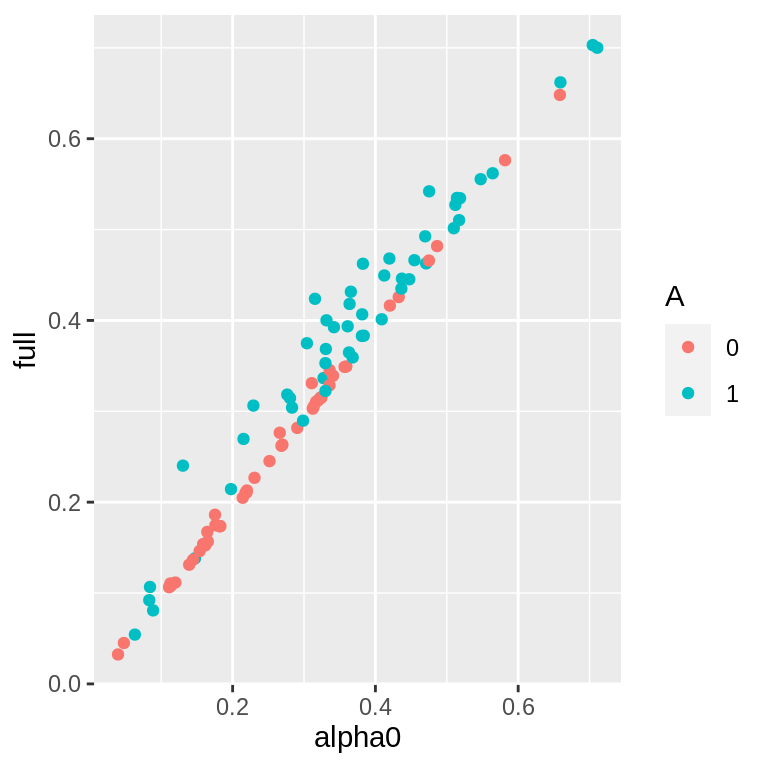

```r
ggplot(df_r2) +
  geom_point(aes(x = alpha0, y = full, color = A))
```

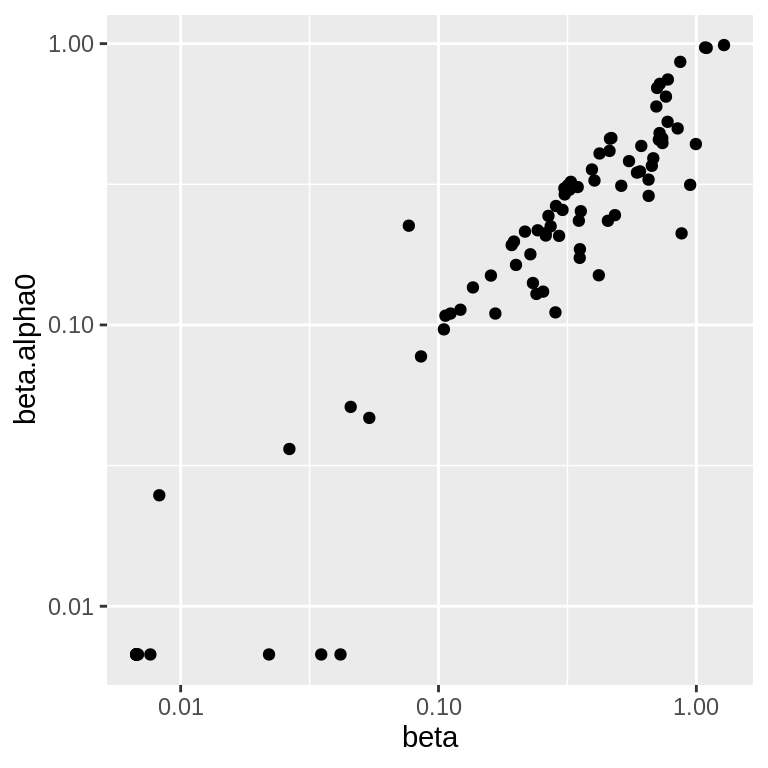

```r
ggplot(df_params) +
  #geom_point(aes(x = alpha, y = alpha.beta0)) +
  geom_point(aes(x = beta, y = beta.alpha0)) +
  #geom_point(aes(x = tau,  y = tau.beta0)) +
  scale_x_log10() + scale_y_log10()
```

```r
# wide to long
df_r2 <- df_r2 %>% pivot_longer(c("full", "alpha0", "beta0", "gamma0", "gamma1", "optimal"),
                                names_to = "lesion", values_to = "r2")

write.csv(df_r2, "../fit/all_r2.csv", row.names = FALSE)

df_r2_summary <- df_r2 %>%
  group_by(A, lesion) %>%
  summarise(r2_m = mean(r2, na.rm = T), r2_se = sd(r2, na.rm = T)/sqrt(n()))
```

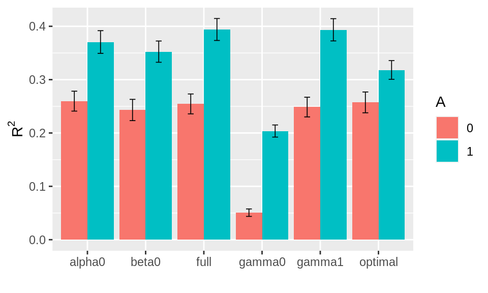

```r
# one R^2 per subject
ggplot(df_r2_summary, aes(x = lesion, fill = A)) +
  geom_bar(aes(y = r2_m), stat = "identity", position = "dodge") +
  geom_errorbar(aes(ymin = r2_m - r2_se, ymax = r2_m + r2_se), position = position_dodge(.9), width = .2, size = .3) +
  labs(y = TeX("$R^2$"), x = "")
```

```r
# ggplot(df_r2, aes(x = lesion, color = A)) +
#   geom_point(aes(y = r2), position = position_jitterdodge(dodge.width = .9, jitter.width = .2))
```

## Optimal agent

An optimal agent would be a GP that has its kernel length scale aligned with the true one, $\alpha = A$. This agent would always take the whole path into account ($\gamma = 1$). But what is the optimal $\beta$ and $\tau$ for each tree?

## Check significance

```r
df_r2_A1 <- df_r2 %>% filter(A == 1)
p <- matrix(nrow = 2, ncol = 4)
p[1,1] <- t.test(r2 ~ lesion, df_r2_A1 %>% filter(lesion %in% c("full", "alpha0")), paired=TRUE)$p.value
p[1,2] <- t.test(r2 ~ lesion, df_r2_A1 %>% filter(lesion %in% c("full", "beta0")),  paired=TRUE)$p.value
p[1,3] <- t.test(r2 ~ lesion, df_r2_A1 %>% filter(lesion %in% c("full", "gamma0")), paired=TRUE)$p.value
p[1,4] <- t.test(r2 ~ lesion, df_r2_A1 %>% filter(lesion %in% c("full", "gamma1")), paired=TRUE)$p.value

df_r2_A0 <- df_r2 %>% filter(A == 0)
p[2,1] <- t.test(r2 ~ lesion, df_r2_A0 %>% filter(lesion %in% c("full", "alpha0")), paired=TRUE)$p.value
p[2,2] <- t.test(r2 ~ lesion, df_r2_A0 %>% filter(lesion %in% c("full", "beta0")),  paired=TRUE)$p.value
p[2,3] <- t.test(r2 ~ lesion, df_r2_A0 %>% filter(lesion %in% c("full", "gamma0")), paired=TRUE)$p.value
p[2,4] <- t.test(r2 ~ lesion, df_r2_A0 %>% filter(lesion %in% c("full", "gamma1")), paired=TRUE)$p.value
p
```

```
##              [,1]         [,2]         [,3]       [,4]
## [1,] 3.856458e-06 6.364502e-08 6.000897e-19 0.78035995
## [2,] 5.076330e-07 5.564009e-03 2.809265e-14 0.03434366
```

```r
t.test(r2 ~ lesion, df_r2_A0 %>% filter(lesion %in% c("full", "gamma1")), paired=TRUE)
```

```
##
##  Paired t-test
##
## data:  r2 by lesion
## t = 2.1794, df = 47, p-value = 0.03434
## alternative hypothesis: true difference in means is not equal to 0
## 95 percent confidence interval:
##  0.0004539552 0.0113447990
## sample estimates:
## mean of the differences
##             0.005899377
```

```r
#wilcox.test(r2 ~ lesion, df_r2_A0 %>% filter(lesion %in% c("full", "gamma1")), paired=TRUE)
```

Likelihood ratio can be tested between two models, but does it make sense to do this on a participant level? One would then have to consider the distribution of $p$ values. Instead we could compare the average nLLs between two models…

```r
library(extRemes)
lr.test(mean(df_alpha0$nLL), mean(df_full$nLL), df = 1)
```

```
##
##  Likelihood-ratio Test
##
## data:  mean(df_alpha0$nLL)mean(df_full$nLL)
## Likelihood-ratio = 9.2567, chi-square critical value = 3.8415, alpha =
## 0.0500, Degrees of Freedom = 1.0000, p-value = 0.002346
## alternative hypothesis: greater
```

# Supplementary analyses

## Tree fits

So far we only looked at parameter fits on the subject level, ignoring the different tree sizes. Here, we fitted parameters for each tree size, ignoring subjects.

```r
df_tree_fits <- read.csv("../fit/all_DE_tree.csv")
df_tree_fits$A <- as.factor(df_tree_fits$A)
df_tree_fits$B <- as.factor(df_tree_fits$B)
df_tree_fits$H <- as.factor(df_tree_fits$H)
```

We first look at exploration parameters:

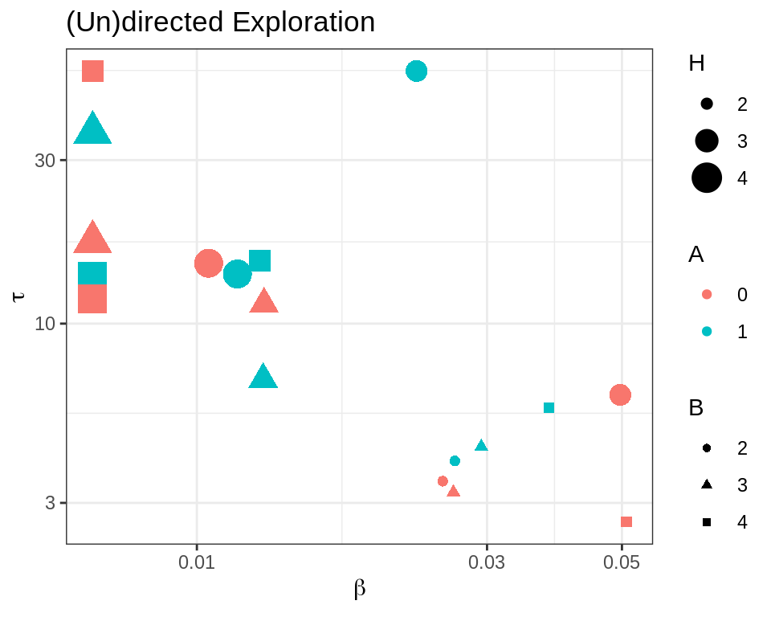

The larger the trees (mainly the higher, $H$), the more random and the less directed exploration. However, we cannot prove this statistically, because there are too little data points.

```r
#m_beta <- lm(beta ~ H + B + H*B, df_tree_fits)
#m_tau <- lm(tau ~ H + B + H*B, df_tree_fits)
#summary(m_beta)
#summary(m_tau)
```

Next, alpha and gamma. NB Gamma should not be interpreted because it did not converge in the fitting!

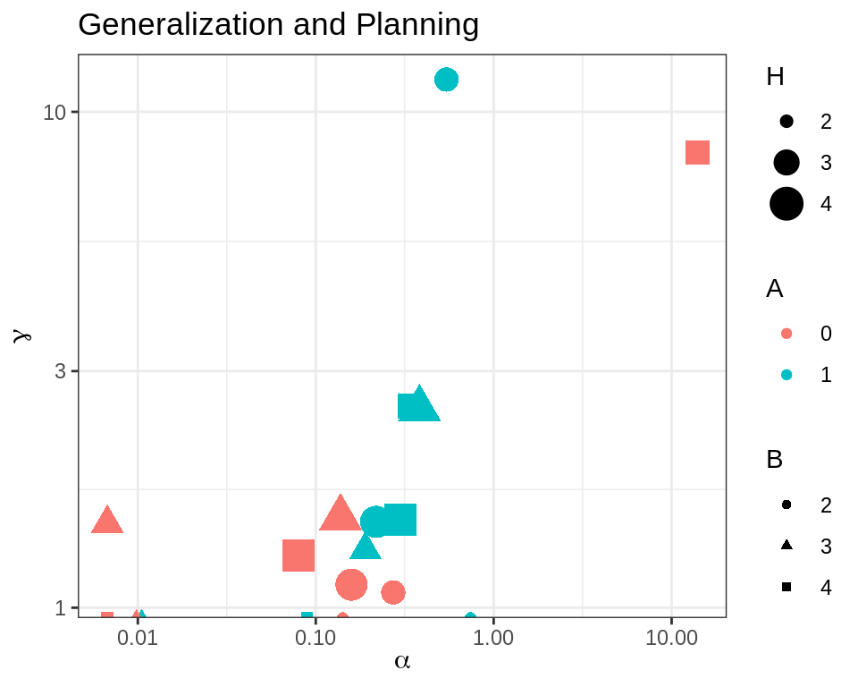

Alpha tends to be smaller for A=0, which makes sense. Again, gamma should not be interpreted here.

## Tree-subject fits

It would be nice to look at the tree fits within subject, however, this is currently not possible, because there would be only 1 city (= 15 walks) per condition which is far too few data points for fitting the full model. TODO We might want to fit a lesioned model (e.g. the optimal one, with alpha = A and gamma = 1) and / or group over one of the tree size dimensions (H or B), so to get 3 times as many data points.